# Loan Data from Prosper

# Multivariate Plots Section

First I want to investigate the relationship above between borrower rate and monthly loan payment against the categorical variables and against Prosper score. This relationship really caught my eye and I want to see if there is more to learn about it.

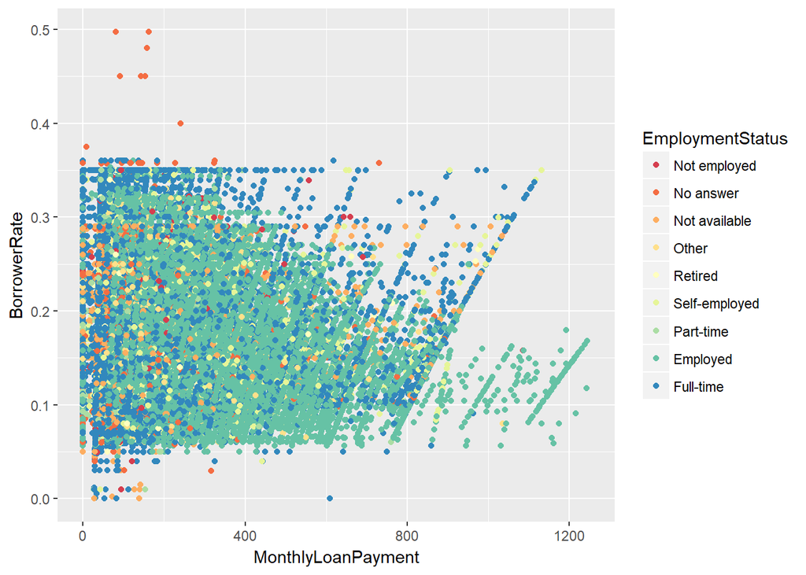

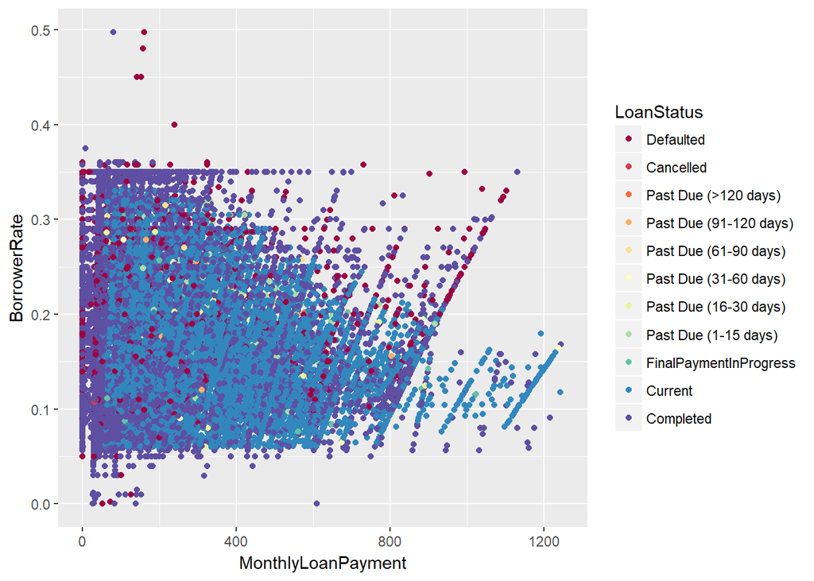

It’s hard to pull any trends out of the data here. Most of the data contains borrowers who are employed or full-time. For loans with low borrower rates and mid-to-high monthly loan payments, its most common for the borrower to be employed.

Most loans are current, completed, or defaulted, but its hard to see any obvious trends.

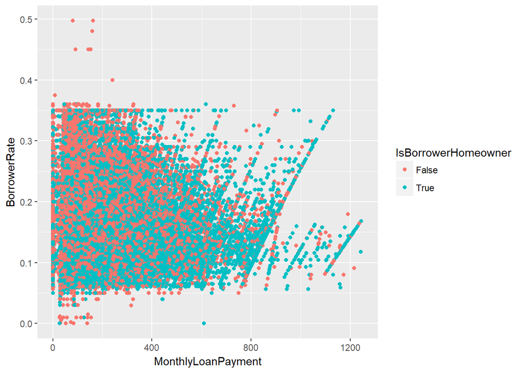

Again, there is no obvious relationship here - homeowners may be slightly more likely to have higher monthly payments and lower borrower rates.

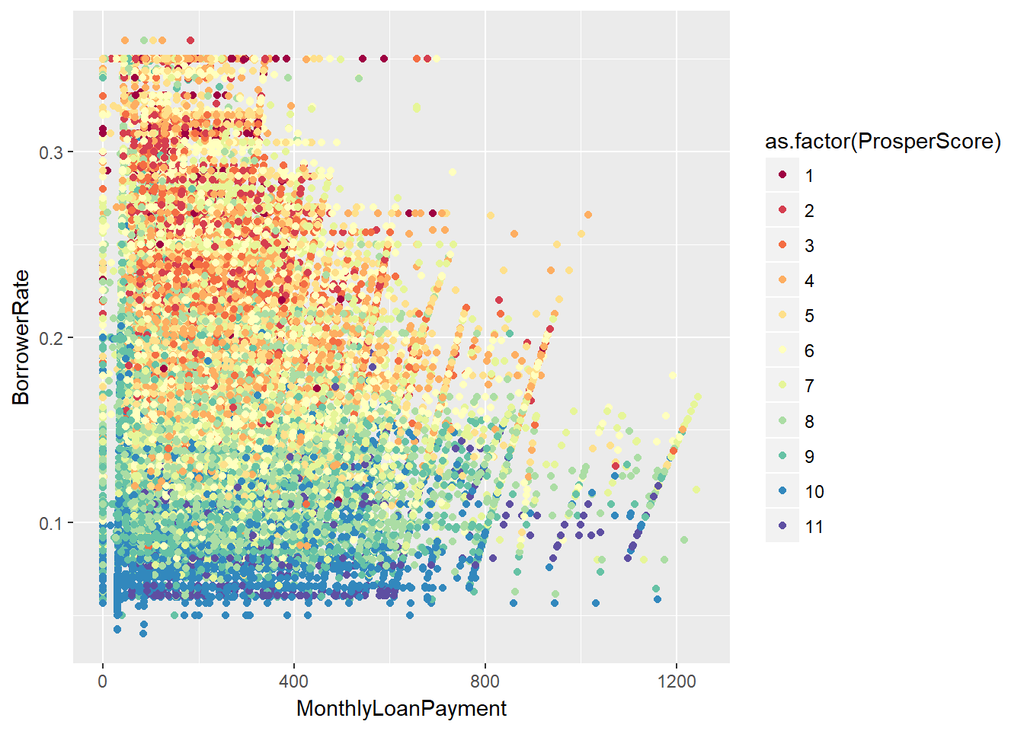

Here there is definitely a relationship, with borrower rate increasing as the Prosper score decreases while holding the monthly loan payment constant. It seems that the linear relationship pieces of the plot noted previously seem to correspond to decreases in Prosper score.

Let us move on and look at Prosper score and borrower rate against the categorical variables.

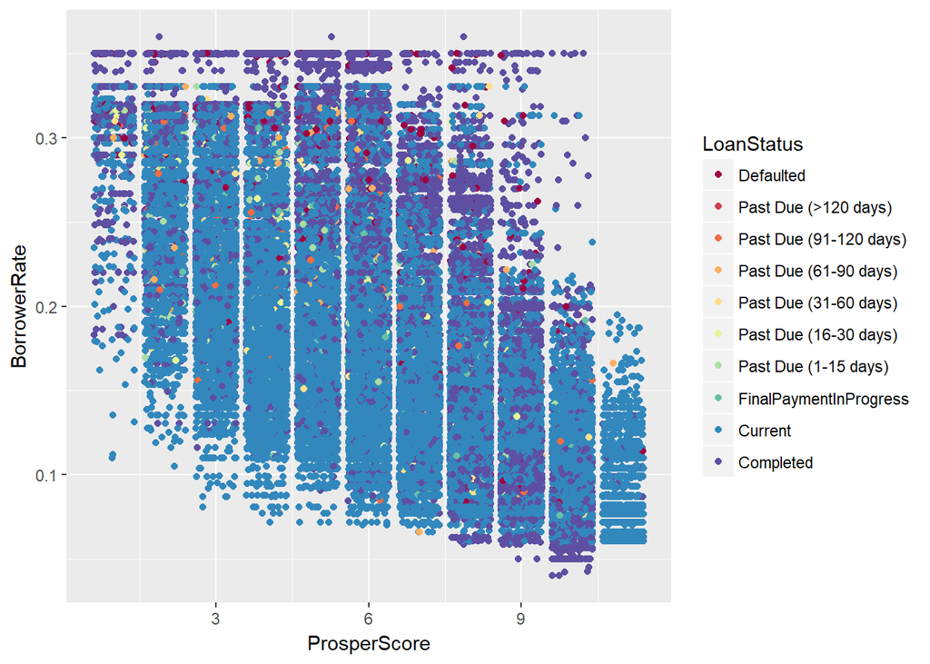

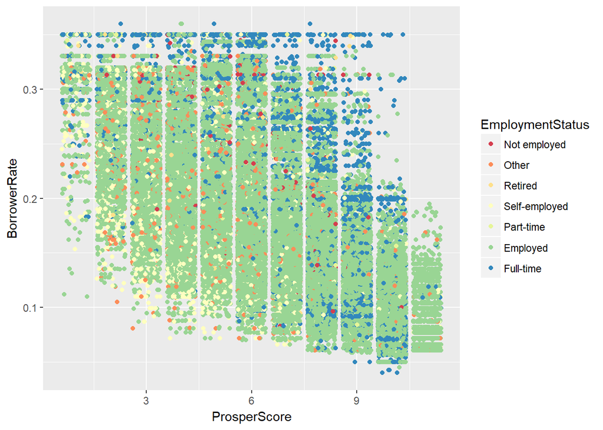

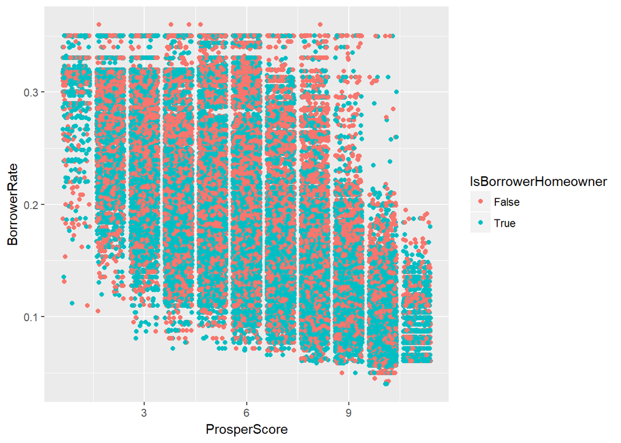

There are no new trends that can be observed from these plots.

Next I want to look at borrower rate and credit score against the categorical variables and also against Prosper score.

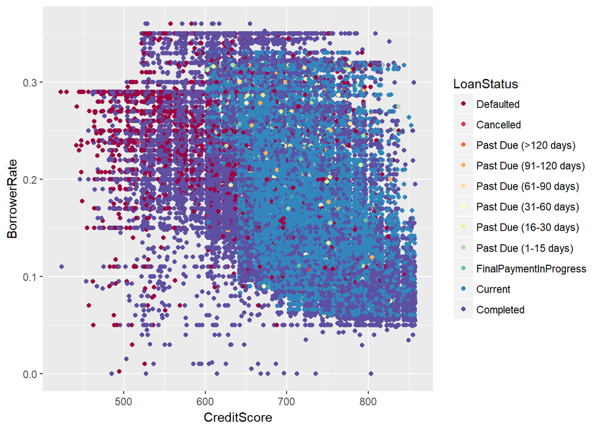

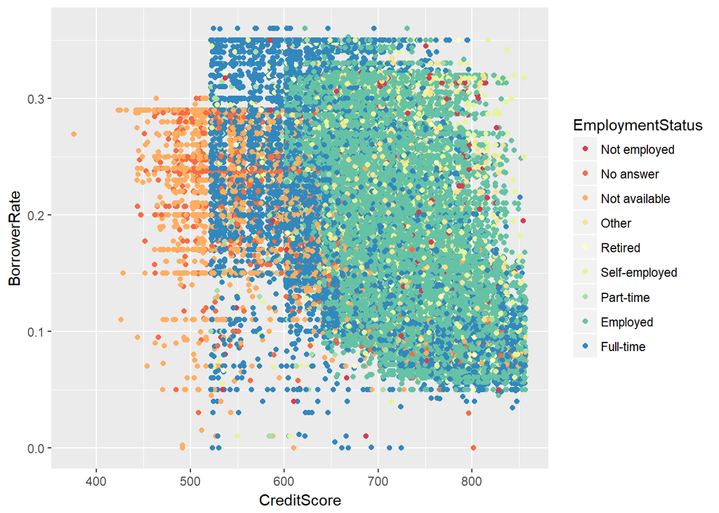

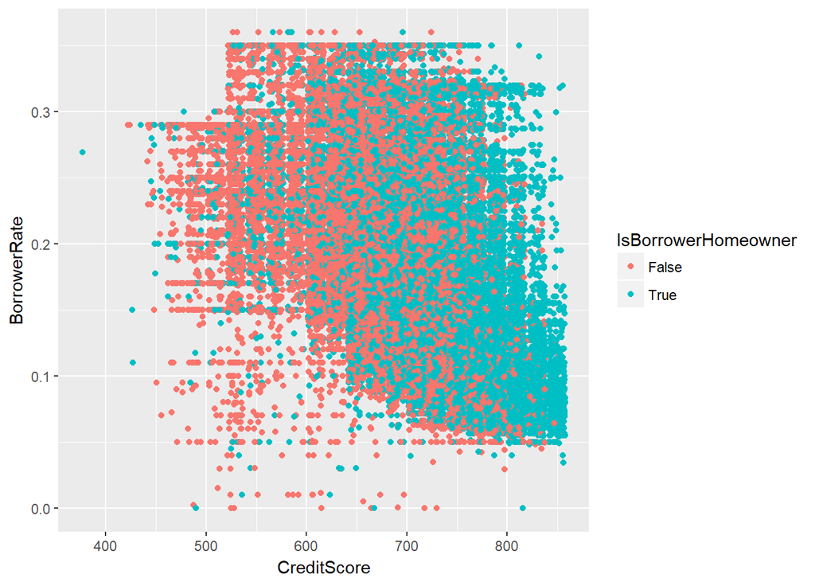

High credit scores tend to correspond to homeowners, while low credit scores correspond to non-homeowners.

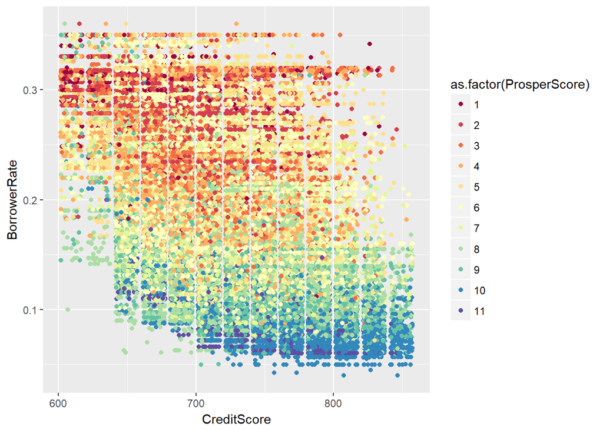

Borrowers with a higher Prosper score tend to have lower borrower rates, even if we hold credit score constant.

At first I had wanted to start out by exploring the Prosper score, but the data exploration has made me more interested in predicting the borrower rate. The plots colored by Prosper score show the moderately strong relationships borrower rate has with other variables in the dataset. I want to create a linear model to see how well we can predict borrower rate.

```
##
## Calls:
## m1: lm(formula = BorrowerRate ~ ProsperScore, data = loans_subset_CreditScore)
## m2: lm(formula = BorrowerRate ~ ProsperScore + CreditScore, data = loans_subset_CreditScore)
## m3: lm(formula = BorrowerRate ~ ProsperScore + CreditScore + MonthlyLoanPayment,
##     data = loans_subset_CreditScore)
##
## ======================================================================
##                             m1              m2              m3
## ----------------------------------------------------------------------
##   (Intercept)               0.317***        0.648***        0.630***
##                            (0.001)         (0.003)         (0.003)
##   ProsperScore             -0.020***       -0.017***       -0.016***
##                            (0.000)         (0.000)         (0.000)
##   CreditScore                              -0.000***       -0.000***
##                                            (0.000)         (0.000)
##   MonthlyLoanPayment                                       -0.000***
##                                                            (0.000)
## ----------------------------------------------------------------------
##   R-squared                 0.421           0.504           0.535
##   adj. R-squared            0.421           0.504           0.535
##   sigma                     0.057           0.052           0.051
##   F                     61498.813       43106.032       32531.390
##   p                         0.000           0.000           0.000
##   Log-likelihood       122853.694      129468.834      132199.794
##   Deviance                272.796         233.352         218.782
##   AIC                 -245701.389     -258929.668     -264389.588
##   BIC                 -245673.348     -258892.280     -264342.853
##   N                     84714           84714           84714
## ======================================================================
```

The model accounts for 53.5% of the variance in the borrower rate for a loan.

# Multivariate Analysis

### Talk about some of the relationships you observed in this part of the investigation. Were there features that strengthened each other in terms of looking at your feature(s) of interest?

Holding monthly loan payments constant, higher Prosper scores generally equate to lower borrower rates. The same relationship can be seen when we hold credit scores constant.

These plots along with the correlations seen in the bivariate plots section led me to create a linear regression model with these variables.

### Were there any interesting or surprising interactions between features?

I was mostly surprised to see the absence of any obvious trends across loan status, employment status, and homeownership (other than credit score).

### OPTIONAL: Did you create any models with your dataset? Discuss the strengths and limitations of your model.

For the amount of variables used in this exploration (compared to the 81 overall variables in the full data set), I think the linear model above is fairly good. With the complexities of all of the factors that go into a loan interest rate, I was surprised to see that Prosper score, credit score, and monthly loan payment alone account for 53.5% of the variance in the borrower rate.

The model obviously has its limitations since there are many other variables that likely affect affect borrower rate in the full data set (and outside it). The date the loan was taken out, the borrower’s state of residence, the type of loan, and many other variables likely have effects on the borrower rate. This is definitely not a perfect model, but I do find it relevant to see that three variables alone can account for over half of the variance in a loan rate.

# Final Plots and Summary

### Plot One

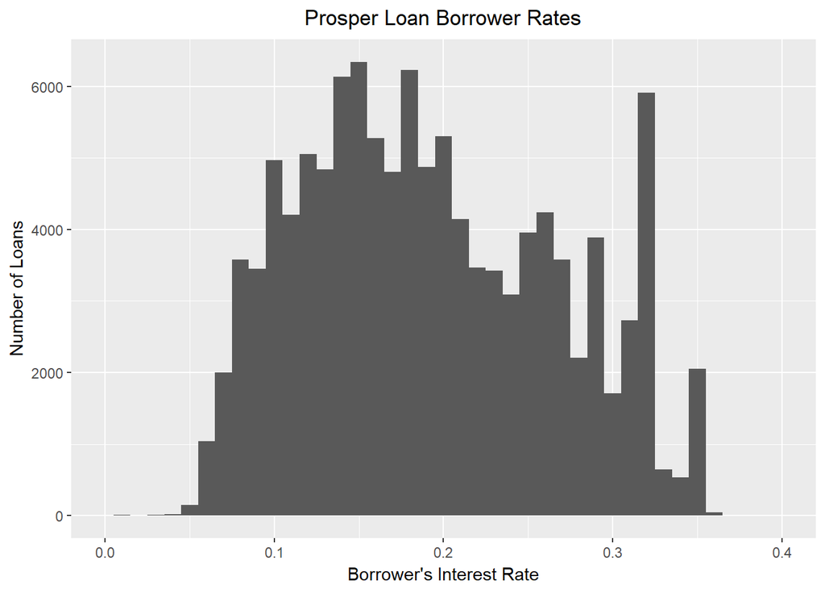

### Description One

The borrower’s interest rate distribution is fairly normal, but contains an interesting peak around 0.31. The loan company may approve some ‘riskier’ borrowers for loans and give them higher interest rates in an attempt to make more money.

### Plot Two

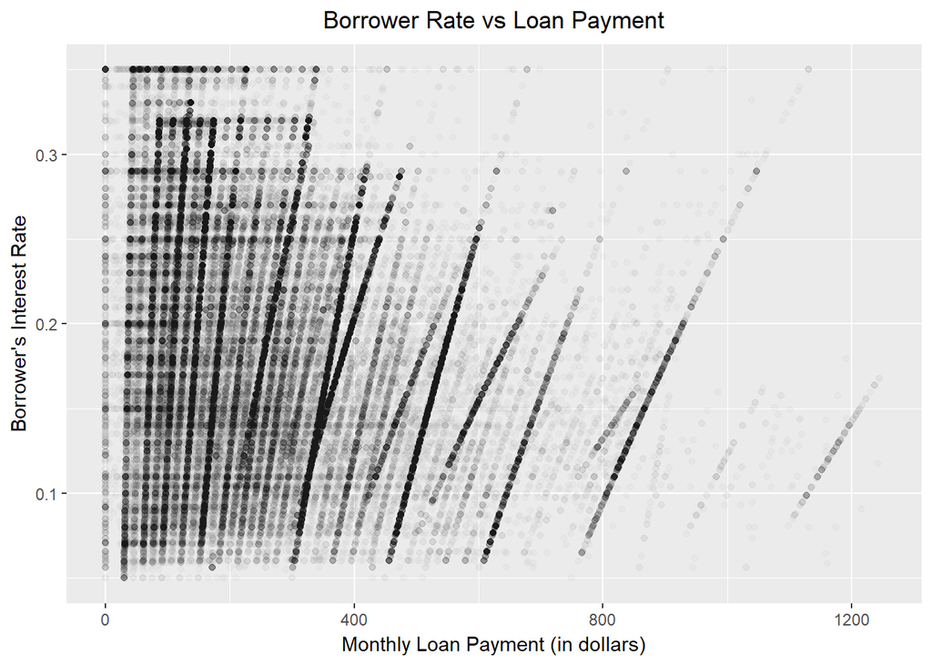

### Description Two

Borrower rate and monthly loan payment have a very interesting relationship as seen here. There are clear linear trends within the plot. At lower monthly loan payments, the borrower rate can rise quickly for the same loan payment. As the monthly loan payments go up, borrower rate and loan payment increase together.

### Plot Three

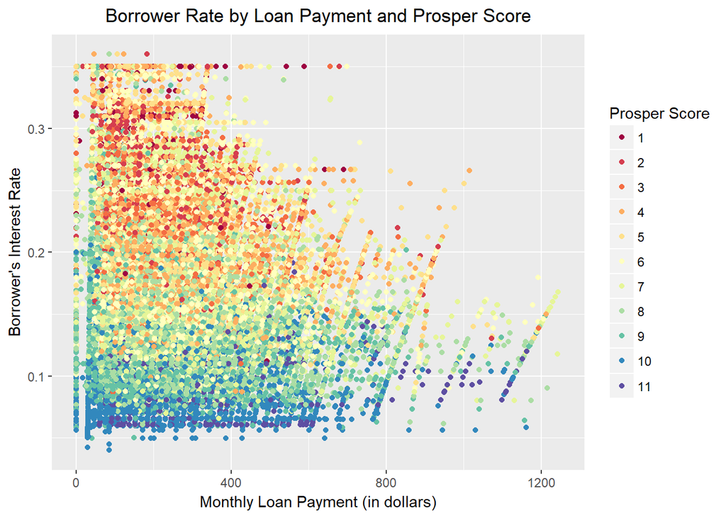

### Description Three

Prosper score gives a better understanding to the relationship between borrower rate and monthly loan payment. Keeping the monthly loan payment constant, the borrower rate increases as Prosper score decreases (indicating a higher risk borrower). As the monthly loan payment increases, the loan company is taking on a higher risk if the borrower does not pay the money back since they will lose more money. For this reason, the loan company increases both the borrower rate and monthly loan payment as the Prosper score decreases. This way, the loan company is able to earn more interest from the borrower if they do pay the loan back. The extra revenue from interest makes it worth it for them to approve the loan with a higher loan payment for riskier borrowers.

# Reflection

The full dataset used here contains almost 114,000 loans with 81 variables. There is a ton of information in the dataset, and in this exploration I decided to focus on 13 variables that peaked my interest.

I began by exploring the individual distributions of the variables in the dataset. Then, I looked at relationships between the variables and further explored the strongest trends. The exploration culminated in an interest in creating a linear model to predict borrower rate based on three of the variables.

Although I started off most interested in Prosper score, the trends among the variables I chose to explore made borrower rate the more intriguing variable. By choosing only 13 variables to explore from the full dataset, I absolutely introduced some limitations to the model. There are many other factors that I did not explore relating to the borrower rate, which is the reason the model only accounts for 53.5% of the variance in borrower rate.

Other limitations include the fact that this data all comes from Prosper. The relationships and models that come from this dataset may be totally different for loans at another company. The dataset also hasn’t been updated since 2014. Loan rates change frequently and so this data may not properly represent the current state of loans.

As mentioned above, there are 81 variables in the full dataset for each loan. I’d be interested in exploring the other variables in depth as well to see which other variables may contribute to borrower rate. With the full dataset, I also think a model could be built to predict the Prosper score. It would be interesting to see which factors go into the generation of a Prosper score and if a model could be built that could accurately predict what a borrower’s Prosper score would be.